# Proporción de población cubierta por red móvil

Antonio Martínez, Julia Palacios, Arturo Pérez, José Enrique Sánchez

21/3/2021

TARGET 9.c - Significantly increase access to information and communications technology and strive to provide universal and affordable access to the Internet in least developed countries by 2020

¿Cual es la proporción de población con acceso a tecnología móvil?

# 1. LECTURA DE DATOS

```r
goal9 <- read_delim(file = "data/goal_9.csv", delim = ";")
```

# 2. TRATAMIENTO DE DATOS

```r
names(goal9)[2] = "Target"
names(goal9)[3] = "Indicator"
names(goal9)[7] = "AverageValue"
names(goal9)[5] = "CountryOrArea"

goal9$AverageValue <- as.numeric(as.character(goal9$AverageValue))

mobile_cov <- goal9 %>%
  select(Target,Indicator,Measure,CountryOrArea,Year,AverageValue,Units) %>%
  filter(Measure %in% c("Proportion of population covered by at least a 3G mobile network ()","Proportion of population covered by at least a 2G mobile network ()","Proportion of population covered by at least a 4G mobile network ()"),
         !grepl('Americas|Asia|Africa|Oceania|Europe|ODA|America|developing|Developed|countries|Countries|regions|Channel', CountryOrArea)) %>%
  complete(Year) %>%
  group_by(CountryOrArea) %>%
  arrange(desc(AverageValue))

mobile_cov_global <- mobile_cov %>%
  group_by(Year,Measure) %>%
    summarize(mean_mobile=mean(AverageValue))
#Calcular la media de todos los paises para cada año
```

# 3. VISUALIZACIÓN

## 3.1 VISUALIZACIÓN DE LA PROPORCION DE POBLACIÓN MUNDIAL CUBIERTA POR RED MÓVIL

Vamos a realizar una visualización global tanto de 2G, 3G como 4G en el mundo.

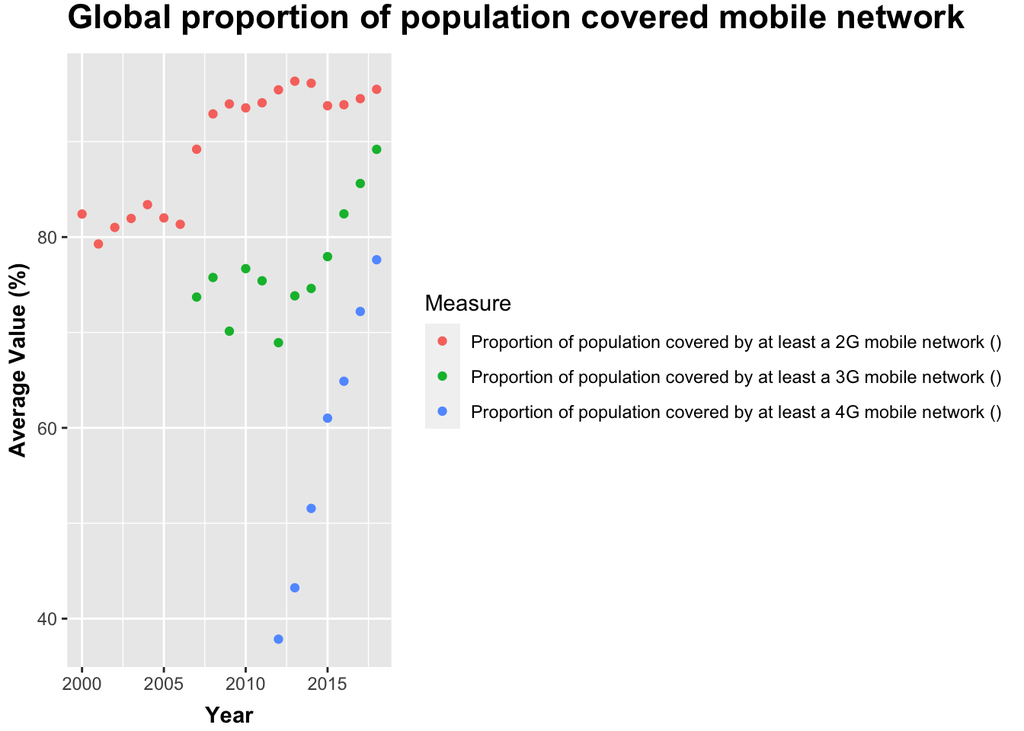

Como podemos observar cada vez hay mas población mundial cubierta por red móvil.

¿Cuales son los países con menor cobertura móvil?

```r
data_rank_mobile <- mobile_cov %>%
  filter(Year == 2018, !is.na(AverageValue),
         Measure %in% c("Proportion of population covered by at least a 4G mobile network ()"),
         !grepl('Americas|Asia|Africa|Oceania|Europe|ODA|America|developing|Developed|countries|Countries|regions|Channel', CountryOrArea)) %>%
  group_by(Year,Measure,CountryOrArea) %>%
    summarize(Mean_population_covered_by_mobile_network=mean(AverageValue))
data_rank_mobile$rank = dense_rank(-data_rank_mobile$Mean_population_covered_by_mobile_network)

data_rank_mobile %>%
  select(CountryOrArea, Mean_population_covered_by_mobile_network, Year, rank) %>% arrange(desc(rank))
```

```
## # A tibble: 132 x 5
## # Groups:   Year, Measure [1]
##    Measure                    CountryOrArea  Mean_population_covere~  Year  rank
##    <chr>                      <chr>                            <dbl> <dbl> <int>
##  1 Proportion of population ~ Djibouti                           5    2018    88
##  2 Proportion of population ~ Afghanistan                        7    2018    87
##  3 Proportion of population ~ Gambia                             7.5  2018    86
##  4 Proportion of population ~ Angola                             8    2018    85
##  5 Proportion of population ~ South Sudan                       10    2018    84
##  6 Proportion of population ~ Chad                              12    2018    83
##  7 Proportion of population ~ Guinea                            18.5  2018    82
##  8 Proportion of population ~ Solomon Islan~                    20    2018    81
##  9 Proportion of population ~ Burundi                           20.9  2018    80
## 10 Proportion of population ~ Nigeria                           22.3  2018    79
## # ... with 122 more rows
```

Djibouti tiene tan solo un 5% de su población cubierta por red móvil 4G, como podemos observar en el top 10 de países con menor cobertura encontramos principalmente países de África.

## 3.2 MOZAMBIQUE: PORCENTAJE DE POBLACIÓN CUBIERTO POR RED MÓVIL

```r
mobile_cov_mz <- mobile_cov %>%
  filter(CountryOrArea=="Mozambique") %>%
  group_by(Year,Measure) %>%
    summarize(mean_mobile=mean(AverageValue))
```

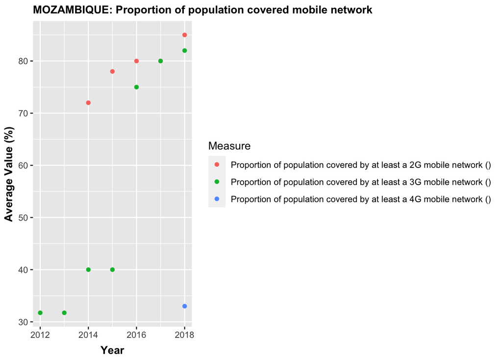

```r
ggplot(mobile_cov_mz, aes( x = Year, y=mean_mobile, color = Measure)) +
  geom_point() +
  ggtitle ("MOZAMBIQUE: Proportion of population covered mobile network") +
    theme (plot.title = element_text(size=rel(1),
                                  vjust=1,
                                  face="bold",
                                  color="black",
                                  lineheight=1.5)) +
    labs(x = "Year",y = "Average Value (%)") +
    theme(axis.title.x = element_text(face="bold", vjust=-0.5, colour="black", size=rel(1))) +
    theme(axis.title.y = element_text(face="bold", vjust=1.5, colour="black", size=rel(1)))
```